# Causal Inference and SEM: Lab 3 - Applications

## 3.2 Analyze the data

We will analyze these data in a variety of ways. Note however that in *none* of the analyses will we be able to include U, as this variable represents the unobserved confounder. That is, we should think of our observed data to consist *only* of the variables: treatment X, pre-test Y1, and post-test Y2.

### 3.2.1 Marginal model

We start with the marginal model, by which we estimate the prima facie effect (see Week 2); this implies we just regress Y2 on X, and assume there is no confounding.

$\blacktriangleright$ What is the marginal effect of X on Y2? How does this compare to the true effect with which you simulated the data?

```r
Y2onX <- lm(Y2 ~ X, data=dat5)
summary(Y2onX)
```

```
##
## Call:
## lm(formula = Y2 ~ X, data = dat5)
##
## Residuals:
##     Min      1Q  Median      3Q     Max
## -4.6682 -0.7977  0.0014  0.7994  4.1755
##
## Coefficients:
##             Estimate Std. Error t value Pr(>|t|)
## (Intercept) 11.28813    0.02355  479.39   <2e-16 ***
## X           -0.07359    0.03329   -2.21   0.0271 *
## ---
## Signif. codes:  0 '***' 0.001 '**' 0.01 '*' 0.05 '.' 0.1 ' ' 1
##
## Residual standard error: 1.177 on 4998 degrees of freedom
## Multiple R-squared:  0.0009767,  Adjusted R-squared:  0.0007768
## F-statistic: 4.886 on 1 and 4998 DF,  p-value: 0.02712
```

### 3.2.2 ANCOVA model

Run an ANCOVA model with X as the predictor of interest, and Y1 as covariate. As Y1 is a proxy of the unmeasured confounder U, including it as a covariate may help to block the backdoor path $X\leftarrow U \rightarrow Y2$ to some extent.

$\blacktriangleright$ What is the effect of X on Y2 in this approach, how would you describe it to others, and how does this compare to the true value?

```r
ANCOVA <- lm(Y2 ~ X + Y1, data=dat5)
summary(ANCOVA)
```

```
##
## Call:
## lm(formula = Y2 ~ X + Y1, data = dat5)
##
## Residuals:
##     Min      1Q  Median      3Q     Max
## -4.5020 -0.7586 -0.0080  0.7739  4.0066
##
## Coefficients:
##             Estimate Std. Error t value Pr(>|t|)
## (Intercept)  8.53842    0.14166  60.274  < 2e-16 ***
## X            0.09283    0.03318   2.798  0.00516 **
## Y1           0.26691    0.01357  19.664  < 2e-16 ***
## ---
## Signif. codes:  0 '***' 0.001 '**' 0.01 '*' 0.05 '.' 0.1 ' ' 1
##
## Residual standard error: 1.134 on 4997 degrees of freedom
## Multiple R-squared:  0.07273,    Adjusted R-squared:  0.07236
## F-statistic:   196 on 2 and 4997 DF,  p-value: < 2.2e-16
```

$\blacktriangleright$ Given the result above, what would you expect the scatter plot of the data (with Y2 plotted against Y1 with different colors for the two groups) to look like? Make this plot.

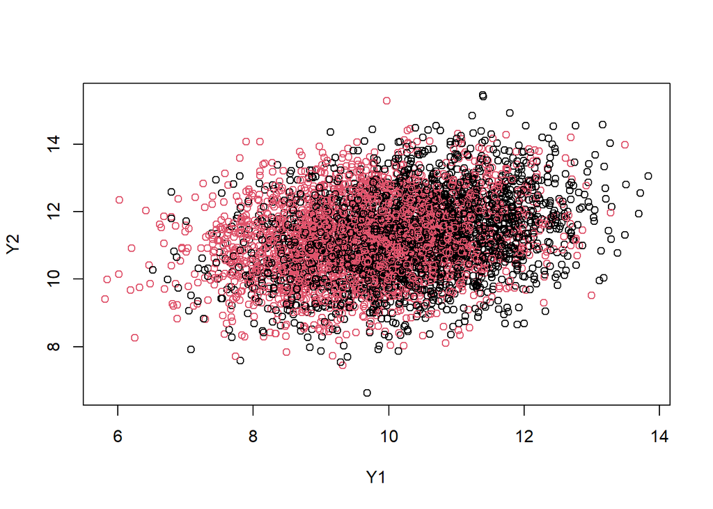

```r
plot(x=dat5$Y1, y=dat5$Y2, col = (dat5$X+1),
        xlab="Y1", ylab="Y2")
```

```r
# Note that in the plot the treatment group (X=1) is in red, and the
# control group (no treatment; X=0) is in black.
```

### 3.2.3 Change score model

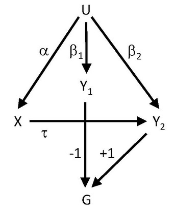

*Fig.4: DAG of repeated measures and unmeasured confounding*

$\blacktriangleright$ Use the DAG to explain why the causal effect of X on the gain score G is the same as the effect of the X on Y2.

$\blacktriangleright$ Run the change score model, with the gain score G=Y2-Y1 as the outcome variable and X as the predictor. What effect do you find, and how does this compare to the true causal effect of X on Y2?

```r
CSA <- lm((Y2-Y1) ~ X, data=dat5)
summary(CSA)
```

```
##
## Call:
## lm(formula = (Y2 - Y1) ~ X, data = dat5)
##
## Residuals:
##     Min      1Q  Median      3Q     Max
## -5.0186 -0.9556  0.0082  0.9700  4.8137
##
## Coefficients:
##             Estimate Std. Error t value Pr(>|t|)
## (Intercept)  0.98598    0.02855   34.54   <2e-16 ***
## X            0.54993    0.04037   13.62   <2e-16 ***
## ---
## Signif. codes:  0 '***' 0.001 '**' 0.01 '*' 0.05 '.' 0.1 ' ' 1
##
## Residual standard error: 1.427 on 4998 degrees of freedom
## Multiple R-squared:  0.03581,    Adjusted R-squared:  0.03561
## F-statistic: 185.6 on 1 and 4998 DF,  p-value: < 2.2e-16
```

$\blacktriangleright$ Based on the results, do you know what to expect if you would make a plot of the means of the groups at pre-test and at post-test? Make the plot, and compare this to your expectations.

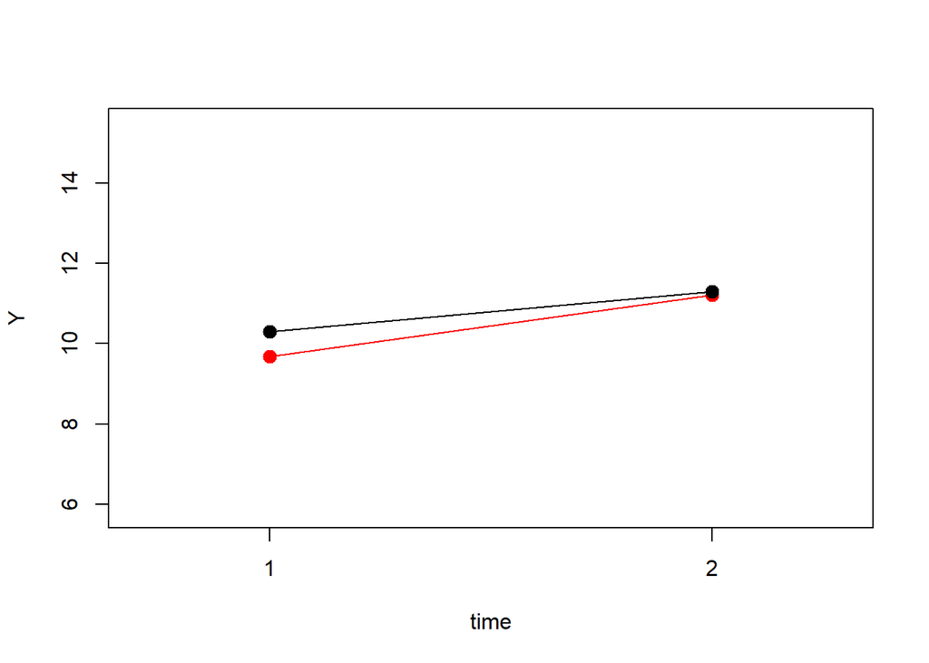

```r
# Compute means at first and second occasion
mY10 <- mean(Y1[X==0])
mY11 <- mean(Y1[X==1])
mY20 <- mean(Y2[X==0])
mY21 <- mean(Y2[X==1])

# Gather means on both occasions per treatment condition
mY0 <- c(mY10,mY20)
mY1 <- c(mY11,mY21)
minY <- min(Y1,Y2)
maxY <- max(Y1,Y2)

# Gather means on both occasions per treatment condition
plot(c(1,2), mY0, type="l",
            xlim=c(0.7,2.3),
            ylim=c(minY,maxY),xaxt="n",
            xlab="time",
            ylab="Y")
lines(c(1,2),mY1,col="red")
points(c(1,2),mY1,pch=19,cex=1.3,col="red")
points(c(1,2),mY0,pch=19,cex=1.3)
axis(side=1, at=seq(1, 2, by=1))
```

```r
# Note again in this plot, the treatment group (X=1) is in red,
# and the control group (no treatment; X=0) is in black.
```

$\blacktriangleright$ Suppose that Y1 and Y2 are measures of math achievement, U is the unobserved math ability, and X is participation in a math camp. How would you explain the results we found above in substantive terms then?

## 3.3 Conclusion

In this exercise you have gained more experience with the gain score model, and the specific scenario in which it should be preferred over doing an ANCOVA: When there is an unmeasured time-invariant confounder that is a common cause of X, Y1, and Y2, and that has a stable effect on Y1 and Y2. Other assumptions are that there are no other relations between the pre-test Y1 and X, or between Y1 and Y2.

We have seen that in this scenario, the marginal model (regressing Y2 on X) leads to a biased estimated of the causal effect of X on Y2, as it does not account for the backdoor path X <- U -> Y2.

We have also seen that including Y1 as a proxy of the unmeasured confounder (regressing Y2 on X and Y1; i.e., ANCOVA), only partly removes this effect.

Here, using a chance score model (regression of gain score Y2-Y1 on X) leads to an unbiased estimate, as the two backdoor paths from X to the gain score G cancel each other out. Kim and Steiner refer to this technique as *off-setting* these paths, rather than *blocking* them (which would require conditioning on a variable along the path).

While this illustrates the elegance of this approach very nicely, we have to realize that the assumptions (mentioned above) are quite strong. Using simulations like these, we could furhter investigate what happens when the effect of U is not stable over time, or when Y1 affects X and/or Y2, or Y1 is affected by X. Such an analysis could help to establish how robust a conclusion (about the strength and sign of the effect of X) is against violations of each of these assumptions.